# Aves de un huerto de paltos y almendros en Paine: quién domina y qué rapaces hay

Borrador 1 del proyecto final (AGP3141)

Autor/a

Laura Escalante

## Introducción

Las plagas de roedores causan pérdidas en la producción agrícola, y las aves rapaces ofrecen una forma ecológica de reducirlas que, además, mantiene la biodiversidad local. Por eso el Proyecto GEF Montaña del Ministerio del Medio Ambiente fomenta el control de plagas con rapaces en predios agrícolas. Este informe analiza los datos de aves de uno de esos predios, El Almendral, un huerto de paltos y almendros en Paine (Alvarado Orellana et al. 2021, GBIF, licencia CC BY 4.0).

## Pregunta de investigación

**¿Cuenta el huerto con las aves que necesita el control de plagas con rapaces, y quién domina su comunidad de aves?**

### Objetivos

1. Identificar qué especies dominan el huerto y cuáles son nativas o introducidas.
2. Describir qué rapaces aparecen en cada monitoreo.

## Datos y diseño de muestreo

El conjunto contiene 407 registros de 38 especies (9 rapaces y 29 no rapaces), con 816 individuos en 8 monitoreos entre diciembre de 2019 y octubre de 2020. Se usaron tres métodos de muestreo, y el esfuerzo cambió durante el estudio (puntos, radio y tiempo), por lo que los monitoreos solo se comparan dentro de un mismo método.

| Método | Registros | Individuos | Especies | Monitoreos |
| --- | --- | --- | --- | --- |
| E: rapaces diurnas, borde plantación-bosque | 69 | 117 | 15 | 8 |
| N: rapaces nocturnas, con playback | 13 | 17 | 3 | 3 |
| U: aves no rapaces, dentro de la plantación | 325 | 682 | 34 | 8 |

*Tabla 1. Registros, individuos, especies y monitoreos por método de muestreo.*

| Monitoreo | Fecha | Individuos | Especies (todos los métodos) |
| --- | --- | --- | --- |
| M1 | 2019-12-27 | 76 | 12 |
| M2 | 2020-01-25 | 99 | 20 |
| M3 | 2020-02-29 | 123 | 19 |
| M4 | 2020-03-28 | 128 | 18 |
| M5 | 2020-05-01 | 154 | 22 |
| M6 | 2020-06-01 | 81 | 20 |
| M7 | 2020-08-28 | 80 | 24 |
| M8 | 2020-10-01 | 75 | 22 |

*Tabla 2. Fecha, individuos y especies registradas en cada monitoreo, con todos los métodos juntos.*

## Hallazgo 1: la especie más abundante es introducida

La especie más abundante es la paloma doméstica (*Columba livia*, introducida), con 110 individuos, seguida de cerca por un tordo nativo (*Curaeus curaeus*, nativa), con 101. En total, las especies introducidas son el 21,2 % de los individuos, y las rapaces apenas el 12 %.

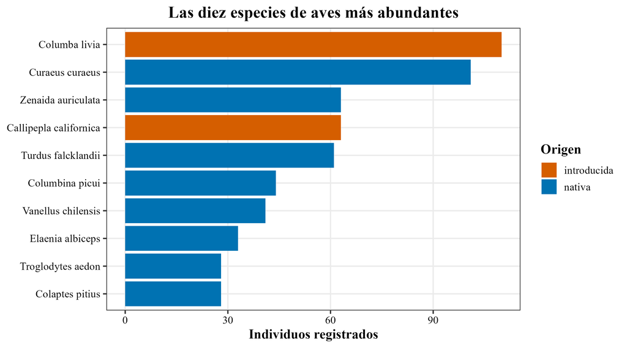

Figura 1. Las diez especies con más individuos en los ocho monitoreos, según origen (nativa o introducida). La paloma doméstica, introducida, es la más abundante y la sigue de cerca una especie nativa.

Dentro de la plantación (método U), la proporción de individuos introducidos varía entre monitoreos: va de 0 % en M7 a 44 % en M4. Es decir, los introducidos llegan a cerca de la mitad de los individuos en un monitoreo y no aparecen en otro. Como cada monitoreo tiene pocos individuos, conviene mirar el tamaño de muestra (n) de cada punto.

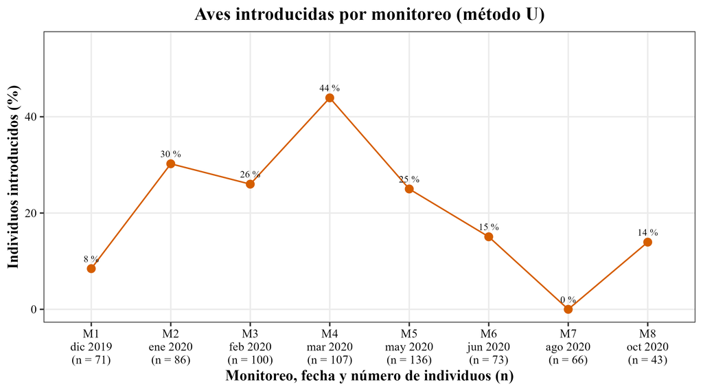

Figura 2. Porcentaje de individuos introducidos en cada monitoreo, método U (dentro de la plantación). Bajo cada punto se indica el mes y el número de individuos (n) de ese monitoreo.

## Hallazgo 2: qué rapaces aparecen y cuándo

Entre las rapaces diurnas hay un recambio durante el año. *Parabuteo unicinctus* (13 de sus 18 individuos) y *Milvago chimango* (12 de 16) se registran sobre todo entre M1 y M4, *Geranoaetus melanoleucus* se mantiene en todos los monitoreos, y *Vultur gryphus* se concentra en M8 (5 de 8 individuos). Son pocos individuos por celda, así que es un patrón para revisar con la tabla de eventos y no una conclusión.

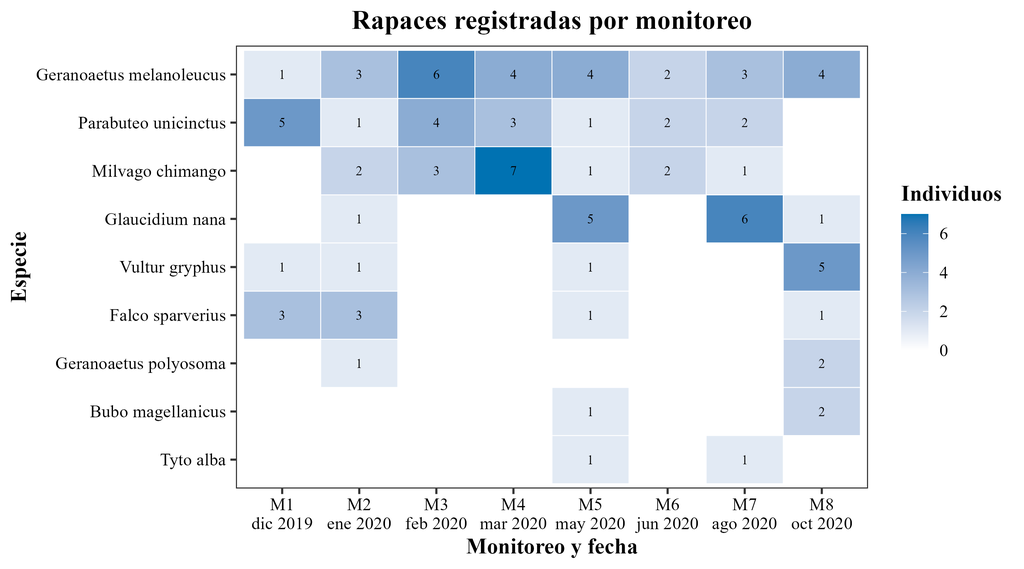

## Discusión

El análisis sugiere que el huerto tiene una comunidad de aves dominada por especies comunes y en parte introducidas, con rapaces presentes pero poco numerosas. Estos resultados son descriptivos: no hay datos de presas ni de plagas, así que no se puede evaluar si las rapaces controlan efectivamente los roedores.

Además, el esfuerzo de muestreo cambió durante el estudio y la tabla de eventos (con los monitoreos sin aves) no está incorporada, por lo que no es posible distinguir un cero real de un monitoreo sin esfuerzo. Por eso las comparaciones se hicieron dentro de un mismo método.

## Conclusión

Este primer borrador describe la comunidad de aves de un huerto de paltos y almendros de Paine, donde la especie más abundante es introducida y una sola rapaz aparece en todos los monitoreos.

Los próximos pasos son incorporar la tabla de eventos, sumar los datos de murciélagos del mismo predio, comparar la riqueza de especies entre monitoreos (con rarefacción) y mejorar el diseño de las figuras.